# Solution to Exam 2009 problem 3

### 02409 Multivariate Statistics

`Week I`

The data originate from an experiment where a supermarket chain randomly assigned different prices (in US dollars) to a house brand of coffee. The coffee was advertised (advertise=1) in a standard way in all cases. The amount of coffee sold (in pounds) was registered. Some weeks later the experiment was conducted again but without advertising (advertise=0). The squared values of the prices are also included in the data (variable: price2).

The first `lm()` corresponds to a regression model with individual intercepts, individual coefficients to the first degree term (price), and individual coeffcients to the second degree term (price2). Consider this model as “M”.

The second `lm()` corresponds to a simplified regression model. Consider this model as “H”.

```r
coffee <- data.frame("pounds" = c(1190,1033,897,789,706,595,512,433,395,304,243,1124,974,830,702,619,529,451,359,296,247,194),
                     "price" = c(3,3.2,3.4,3.6,3.8,4,4.2,4.4,4.6,4.8,5,3,3.2,3.4,3.6,3.8,4,4.2,4.4,4.6,4.8,5),
                     "advertise" = c(1,1,1,1,1,1,1,1,1,1,1,0,0,0,0,0,0,0,0,0,0,0),
                     "price2" = c(9,10.24,11.56,12.96,14.44,16,17.64,19.36,21.16,23.04,25,9,10.24,11.56,12.96,14.44,16,17.64,19.36,21.16,23.04,25))
coffee$advertise <- as.factor(coffee$advertise)
```

## Question 3.1.

The reduction in the fraction of variance explained going from model M to model H is given by the difference in R-square in the output. See section 3.1.2 in the book.

```r
# Model "M"
lmM <- lm(pounds~ advertise + price%in%(advertise) + price2%in%(advertise),data=coffee)
AnoM = anova(lmM)
SumM = summary(lmM)
```

```r
# Model "H"
lmH <- lm(pounds~ advertise + price + price2,data=coffee)
AnoH = anova(lmH)
SumH = summary(lmH)
```

```r
# Question 3.1
SumM$r.squared - SumH$r.squared
```

```
## [1] 0.0001567816
```

$0.998315 - 0.998159 = 0.000156$, i.e. answer 4.

## Question 3.2.

We are asked:

$||P_M (\boldsymbol{Y}) -P_H (\boldsymbol{Y})||^2$ equals:

This can be calculated in two ways, see e.g. exercise 3.6, and remark 2.28 in the book.

We find the relevant output in R:

```r
print("Anova Type I SS (Model 'M'):")
AnoM
print("Anova Type I SS (Model 'H'):")
AnoH
```

```
## [1] "Anova Type I SS (Model 'M'):"
```

```
## Analysis of Variance Table
##
## Response: pounds
##                  Df  Sum Sq Mean Sq F value    Pr(>F)
## advertise         1   27090   27090  134.96 3.287e-09 ***
## advertise:price   2 1832220  916110 4563.80 < 2.2e-16 ***
## advertise:price2  2   44042   22021  109.70 4.554e-10 ***
## Residuals        16    3212     201
## ---
## Signif. codes:  0 '***' 0.001 '**' 0.01 '*' 0.05 '.' 0.1 ' ' 1
```

```
## [1] "Anova Type I SS (Model 'H'):"
```

```
## Analysis of Variance Table
##
## Response: pounds
##           Df  Sum Sq Mean Sq F value    Pr(>F)
## advertise  1   27090   27090  138.90 6.743e-10 ***
## price      1 1832209 1832209 9394.18 < 2.2e-16 ***
## price2     1   43754   43754  224.34 1.321e-11 ***
## Residuals 18    3511     195
## ---
## Signif. codes:  0 '***' 0.001 '**' 0.01 '*' 0.05 '.' 0.1 ' ' 1
```

```r
sum(AnoM$`Sum Sq`[1:3]) - sum(AnoH$`Sum Sq`[1:3])
```

```
## [1] 298.9142
```

```r
tail(AnoH$`Sum Sq`,1) - tail(AnoM$`Sum Sq`,1)
```

```
## [1] 298.9142
```

One way is using the model SS:
$$||P_M (\boldsymbol{Y}) -P_H (\boldsymbol{Y})||^2 = SS_{model}(M) -
SS_{model}(H) = 1903352.075 - 1903053.160 = 298.9150$$

Another is using the Error SS (Residual SS):

$$||P_M (\boldsymbol{Y}) -P_H (\boldsymbol{Y})||^2 = SS_{error}(H) -
SS_{error}(H) = 3510.658 - 3211.744 = 298.9140$$

With the difference being due to rounding errors. We see that the correct answer is 5.

## Question 3.3.

*k - r* equals?

We look at section 2.2.1, and figure 2.4. From the figure, it is apparent, that k is the dimension of the model space M, and *r* is the dimension of the hypothesis space H.

In the code we notice, that we have an intercept (in the `summary()` function). This can also be seen from the output, as the “Corrected Total” is used (see explanation 2.33 p.147).

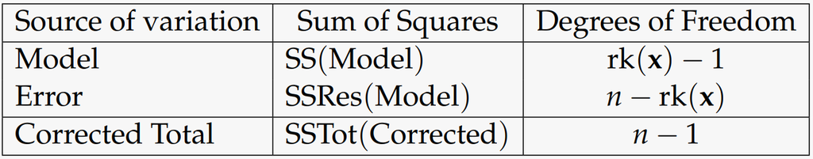

$k$ is thus $5+1=6$, and $r$ is $3+1=4$, and $k-r$ is $6-4=2$

It can be however also be found in two different ways:
$$k - r = DF_{model}(M) - DF_{model}(H) = 5 - 3 = 2$$
$$k - r = DF_{error}(H) - DF_{error}(M) = 18 - 16 = 2$$

Leading us to answer 2.

In R:

```r
sum(AnoM$Df[1:3]) - sum(AnoH$Df[1:3])
```

```
## [1] 2
```

```r
tail(AnoH$Df,1) - tail(AnoM$Df,1)
```

```
## [1] 2
```

## Question 3.4.

$||\boldsymbol{Y} - P_M (\boldsymbol{Y})||^2$ equals:

This is the difference between the observed values and our model, i.e. the Residuals, or sum of squared errors. We can read it directly from the `anova()` output:

```r
print("Anova Type I SS (Model 'M'):")
AnoM
tail(AnoM$`Sum Sq`,1)
```

```
## [1] "Anova Type I SS (Model 'M'):"
```

```
## Analysis of Variance Table
##
## Response: pounds
##                  Df  Sum Sq Mean Sq F value    Pr(>F)
## advertise         1   27090   27090  134.96 3.287e-09 ***
## advertise:price   2 1832220  916110 4563.80 < 2.2e-16 ***
## advertise:price2  2   44042   22021  109.70 4.554e-10 ***
## Residuals        16    3212     201
## ---
## Signif. codes:  0 '***' 0.001 '**' 0.01 '*' 0.05 '.' 0.1 ' ' 1
```

```
## [1] 3211.744
```

Answer 1.

## Question 3.5.

*n - k* equals:

This the degrees of freedom for the residual or error. We look again in the output:

```r
print("Anova Type I SS (Model 'M'):")
AnoM
tail(AnoM$Df,1)
```

```
## [1] "Anova Type I SS (Model 'M'):"
```

```
## Analysis of Variance Table
##
## Response: pounds
##                  Df  Sum Sq Mean Sq F value    Pr(>F)
## advertise         1   27090   27090  134.96 3.287e-09 ***
## advertise:price   2 1832220  916110 4563.80 < 2.2e-16 ***
## advertise:price2  2   44042   22021  109.70 4.554e-10 ***
## Residuals        16    3212     201
## ---
## Signif. codes:  0 '***' 0.001 '**' 0.01 '*' 0.05 '.' 0.1 ' ' 1
```

```
## [1] 16
```

Answer 3.